# Principal Components Analysis

# Data: Wine

You must read the data before trying to run code on your own machine. To read data use the following code after setting your working directory. To set your working directory, modify the following to set the file path for the folder where the data file resides. `setwd('c:/thatawesomeclass/)`

```r
wine = read.table('wine_m4.csv',header=TRUE,sep=';')
```

# Explore Data

This dataset contains information on chemical properties of a set of wines (e.g., fixed acidity, alcohol) and a rating of quality.

```r
str(wine)
```

```
## 'data.frame':    4898 obs. of  12 variables:
##  $ fixed.acidity       : num  7 6.3 8.1 7.2 7.2 8.1 6.2 7 6.3 8.1 ...
##  $ volatile.acidity    : num  0.27 0.3 0.28 0.23 0.23 0.28 0.32 0.27 0.3 0.22 ...
##  $ citric.acid         : num  0.36 0.34 0.4 0.32 0.32 0.4 0.16 0.36 0.34 0.43 ...
##  $ residual.sugar      : num  20.7 1.6 6.9 8.5 8.5 6.9 7 20.7 1.6 1.5 ...
##  $ chlorides           : num  0.045 0.049 0.05 0.058 0.058 0.05 0.045 0.045 0.049 0.044 ...
##  $ free.sulfur.dioxide : num  45 14 30 47 47 30 30 45 14 28 ...
##  $ total.sulfur.dioxide: num  170 132 97 186 186 97 136 170 132 129 ...
##  $ density             : num  1.001 0.994 0.995 0.996 0.996 ...
##  $ pH                  : num  3 3.3 3.26 3.19 3.19 3.26 3.18 3 3.3 3.22 ...
##  $ sulphates           : num  0.45 0.49 0.44 0.4 0.4 0.44 0.47 0.45 0.49 0.45 ...
##  $ alcohol             : num  8.8 9.5 10.1 9.9 9.9 10.1 9.6 8.8 9.5 11 ...
##  $ quality             : int  6 6 6 6 6 6 6 6 6 6 ...
```

# Prepare Data

## Missing Values

Principal Components Analysis uses data on all variables. A missing observation on one variable will cause the entire row of data to be ignored for analysis. Therefore, it is important to impute missing values. These can be imputed using any of a variety of imputation functions available in packages such as mice, caret, and missMDA

## Standardize variables

It is important to standardize variables to ensure they receive the same weight in analysis. We do not need to standardize at this stage because the principal components analysis functions we will be using include an argument for standardizing variables.

## Split Data

```r
library(caret)
set.seed(1706)
split = createDataPartition(y=wine$quality,p = 0.7,list = F,groups = 100)
train_wine = wine[split,]
test_wine = wine[-split,]
```

## Drop Outcome Variable

Drop the outcome variable, ** quality **, from train and test sets. Only keeping variables to be reduced to fewer components

```r
train = train_wine[,1:11]
test = test_wine[,1:11]
```

# Suitability for Principal Components Analysis

Principal Components Analysis is used to reduce the dimensionality of the data by representing a large number of variables with a fewer number of components. Similar variables get grouped into the same component while dissimilar variables are placed in different components.

## Correlations

Similarity is typically judged by the correlation. Presence of large correlations in the data indicates similarity in the data. From the perspective of supervised learning techniques, correlated variables indicate redundancy.

```r
round(cor(train,use='complete.obs'), 3)
```

```
##                      fixed.acidity volatile.acidity citric.acid residual.sugar
## fixed.acidity                1.000           -0.030       0.291          0.100
## volatile.acidity            -0.030            1.000      -0.149          0.082
## citric.acid                  0.291           -0.149       1.000          0.075
## residual.sugar               0.100            0.082       0.075          1.000
## chlorides                    0.035            0.069       0.125          0.101
## free.sulfur.dioxide         -0.031           -0.096       0.077          0.297
## total.sulfur.dioxide         0.096            0.088       0.107          0.410
## density                      0.266            0.042       0.130          0.849
## pH                          -0.439           -0.033      -0.151         -0.205
## sulphates                   -0.002           -0.066       0.059         -0.044
## alcohol                     -0.121            0.064      -0.053         -0.458
##                      chlorides free.sulfur.dioxide total.sulfur.dioxide density
## fixed.acidity            0.035              -0.031                0.096   0.266
## volatile.acidity         0.069              -0.096                0.088   0.042
## citric.acid              0.125               0.077                0.107   0.130
## residual.sugar           0.101               0.297                0.410   0.849
## chlorides                1.000               0.088                0.193   0.262
## free.sulfur.dioxide      0.088               1.000                0.618   0.289
## total.sulfur.dioxide     0.193               0.618                1.000   0.525
## density                  0.262               0.289                0.525   1.000
## pH                      -0.098               0.000                0.001  -0.105
## sulphates                0.007               0.053                0.119   0.057
## alcohol                 -0.359              -0.240               -0.442  -0.770
##                          pH sulphates alcohol
## fixed.acidity        -0.439    -0.002  -0.121
## volatile.acidity     -0.033    -0.066   0.064
## citric.acid          -0.151     0.059  -0.053
## residual.sugar       -0.205    -0.044  -0.458
## chlorides            -0.098     0.007  -0.359
## free.sulfur.dioxide   0.000     0.053  -0.240
## total.sulfur.dioxide  0.001     0.119  -0.442
## density              -0.105     0.057  -0.770
## pH                    1.000     0.151   0.133
## sulphates             0.151     1.000  -0.005
## alcohol               0.133    -0.005   1.000
```

Visualizing the matrix to spot high correlations may be easier. Here, we use ggplot2 to construct a correlation matrix. High correlations indicates pairwise similarity.

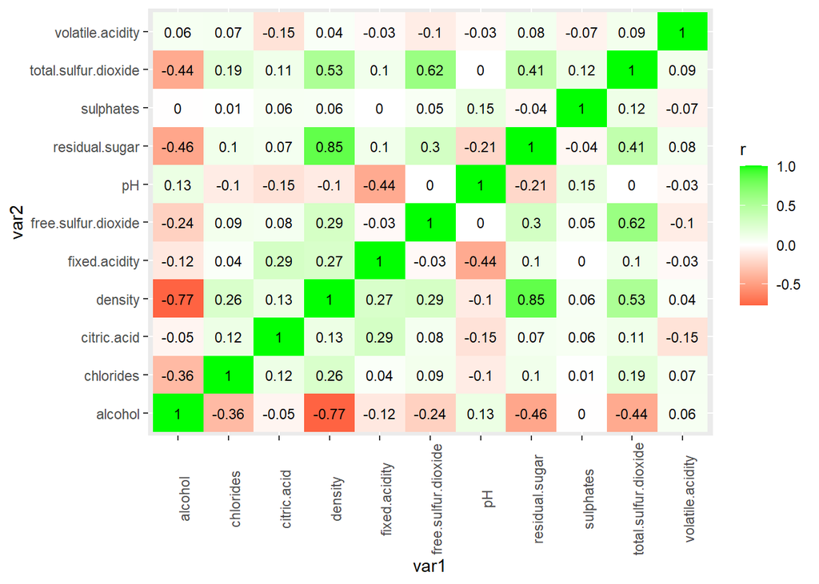

```r
library(tidyr); library(dplyr); library(ggplot2)
corMatrix = as.data.frame(cor(train))
corMatrix$var1 = rownames(corMatrix)
corMatrix %>%
  gather(key=var2,value=r,1:11)%>%
  ggplot(aes(x=var1,y=var2,fill=r))+
  geom_tile()+
  geom_text(aes(label=round(r,2)),size=3)+
  scale_fill_gradient2(low = 'red',high='green',mid = 'white')+
  theme(axis.text.x=element_text(angle=90))
```

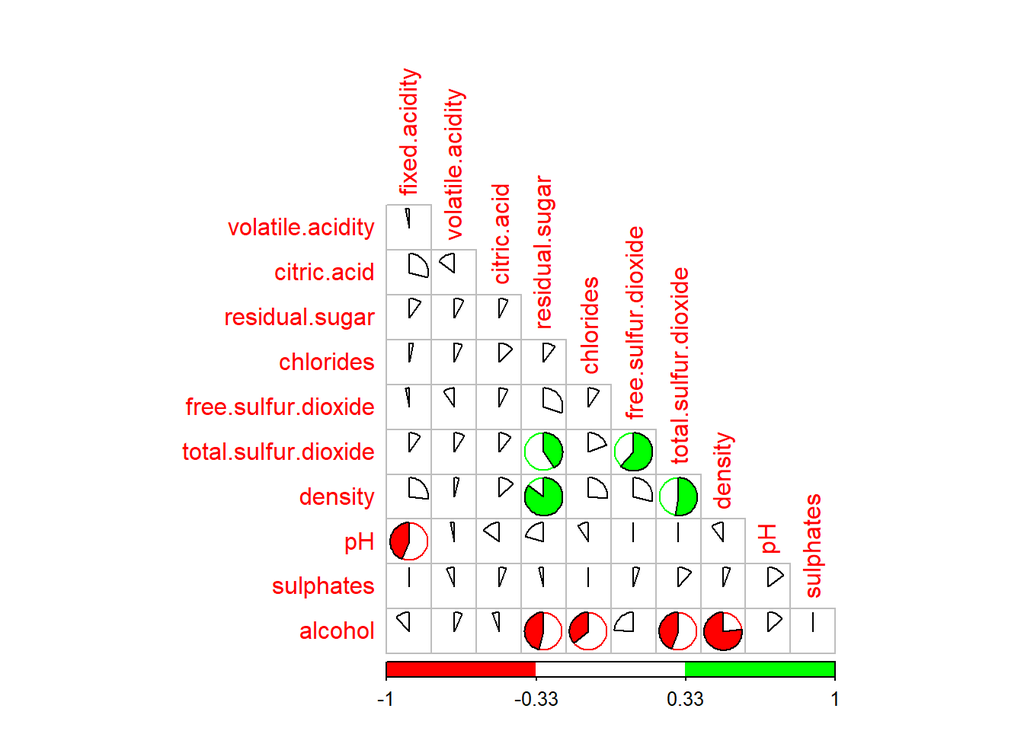

```r
library(corrplot)
corrplot(cor(train),type = 'lower',col = c('red','white','green'),method = 'pie',diag = F,order='original')
```

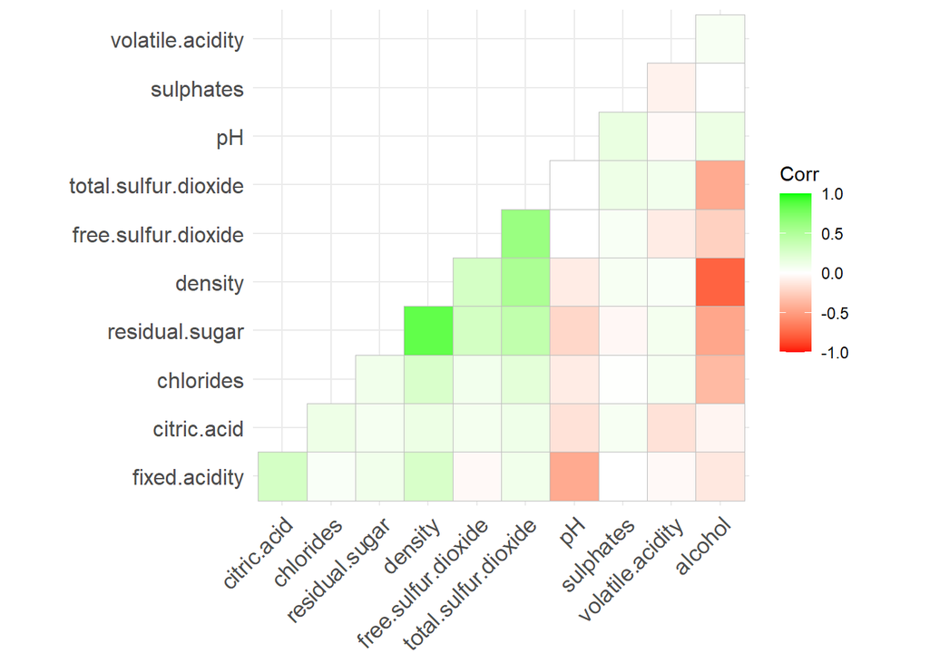

```r
library(ggcorrplot)
ggcorrplot(cor(train),colors = c('red','white','green'),hc.order = T,type = 'lower')
```

## Bartlett’s Test of Sphericity

Looks to see if there are at least some non-zero correlations by comparing correlation matrix to an identity matrix. A significant test indicates suitability for principal component analysis.

```r
library(psych)
cortest.bartlett(cor(train),n = nrow(train))
```

```
## $chisq
## [1] 17203.22
##
## $p.value
## [1] 0
##
## $df
## [1] 55
```

## KMO Measure of Sampling Adequacy (MSA)

Compares partial correlation matrix to pairwise correlation matrix. A partial correlation is a correlation after partialing out all other correlations. If the variables are strongly related, partial correlations should be small and MSA close to 1. If MSA > 0.5, data is suitable for principal component analysis.

```r
KMO(cor(train))
```

```
## Kaiser-Meyer-Olkin factor adequacy
## Call: KMO(r = cor(train))
## Overall MSA =  0.38
## MSA for each item =
##        fixed.acidity     volatile.acidity          citric.acid
##                 0.18                 0.23                 0.68
##       residual.sugar            chlorides  free.sulfur.dioxide
##                 0.34                 0.66                 0.59
## total.sulfur.dioxide              density                   pH
##                 0.72                 0.41                 0.17
##            sulphates              alcohol
##                 0.19                 0.37
```

# Determine Number of Components

A dataset with p variables will generate p components. Our goal is to pick out the top few components that capture most of the variance in the original data.

There are a number of functions for conducing principal components analysis including prcomp (from stats package), principal (from psych), caret, PCA (from FactoMineR), and dudi.pca (from ade4). The final results from principal components analysis are the same for all functions. The differences are in the optional arguments, helper functions and presentation of results. Here, we illustrate the use of two different functions: stats::prcomp and FactoMineR::PCA. We also use library(factoextra) to visualize the results.

## Scree Plot

Line graph of eigen values for each component. Ideal number of components is indicated by a sudden change in the line graph or what is known as the elbow.

Using FactoMineR

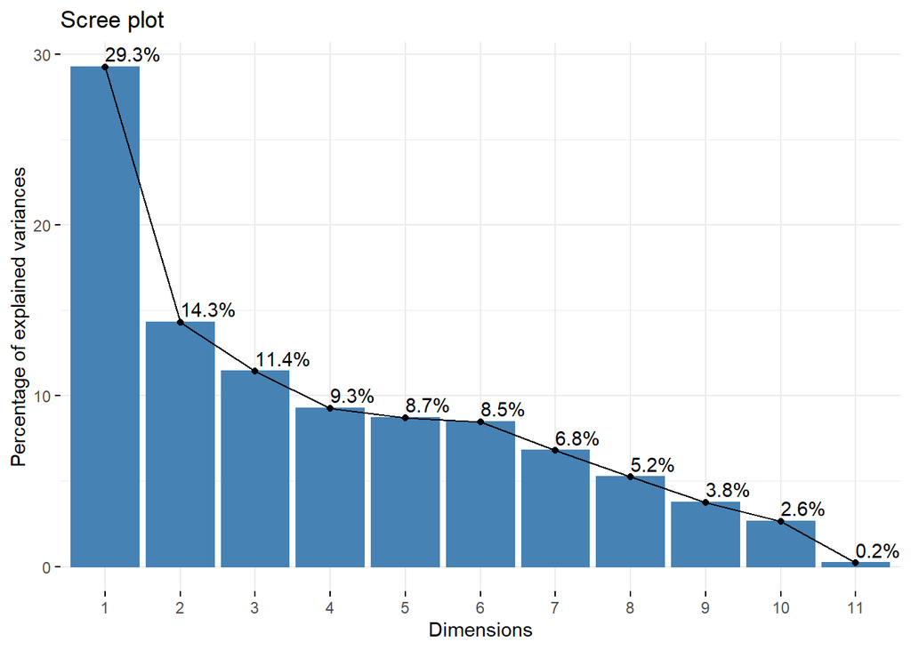

```r
library(FactoMineR)
pca_facto = PCA(train,graph = F)
library(factoextra)
fviz_eig(pca_facto,ncp=11,addlabels = T)
```

```r
#fviz_eig(pca)
```

Using prcomp

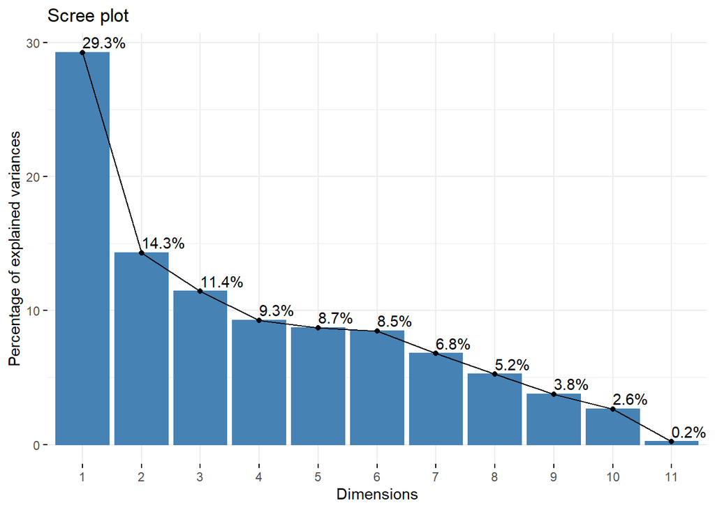

```r
pca = prcomp(train,scale. = T)
fviz_eig(pca,ncp = 11,addlabels = T)
```

## Eigen Value

According to the eigen-value criterion, all components with eigen value greater than 1 are selected.

Using library(FactoMineR)

```r
pca_facto$eig
```

```
##         eigenvalue percentage of variance cumulative percentage of variance
## comp 1  3.21772952              29.252087                          29.25209
## comp 2  1.57098677              14.281698                          43.53378
## comp 3  1.25618853              11.419896                          54.95368
## comp 4  1.01829095               9.257190                          64.21087
## comp 5  0.95825442               8.711404                          72.92227
## comp 6  0.93142123               8.467466                          81.38974
## comp 7  0.74610042               6.782731                          88.17247
## comp 8  0.57619368               5.238124                          93.41060
## comp 9  0.41366920               3.760629                          97.17122
## comp 10 0.28894120               2.626738                          99.79796
## comp 11 0.02222408               0.202037                         100.00000
```

```r
pca_facto$eig[pca_facto$eig[,'eigenvalue']>1,]
```

```
##        eigenvalue percentage of variance cumulative percentage of variance
## comp 1   3.217730               29.25209                          29.25209
## comp 2   1.570987               14.28170                          43.53378
## comp 3   1.256189               11.41990                          54.95368
## comp 4   1.018291                9.25719                          64.21087
```

Using prcomp

```r
data.frame(component = 1:length(pca$sdev), eigen_value = (pca$sdev)^2)
```

| component | eigen_value |
| --- | --- |
| 1 | 3.21772952 |
| 2 | 1.57098677 |
| 3 | 1.25618853 |
| 4 | 1.01829095 |
| 5 | 0.95825442 |
| 6 | 0.93142123 |
| 7 | 0.74610042 |
| 8 | 0.57619368 |
| 9 | 0.41366920 |
| 10 | 0.28894120 |

[output cut: 1 more lines]

## Parallel Analysis

Simulate a dataset with same variables and observations as original dataset. Compute correlation matrix and eigen values. Now, compare eigen values from simulated data to original data. Select components with eigen values in the original data greater than eigen values in the simulated data.

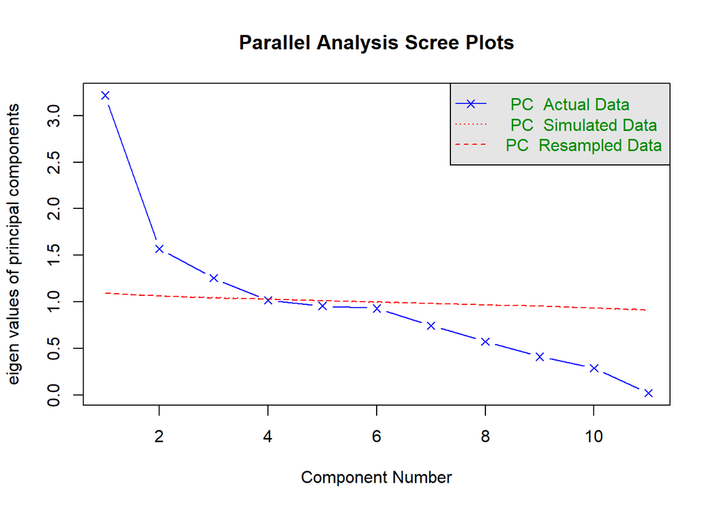

```
## Parallel analysis suggests that the number of factors =  NA  and the number of components =  3
```

```r
library(psych)
fa.parallel(train,fa='pc')
```

## Total Variance Explained

To ensure that the principal components represent the original variables sufficiently well, the total variance explained by principal components should be greater than 70%.

```r
pca_facto$eig
```

```
##         eigenvalue percentage of variance cumulative percentage of variance
## comp 1  3.21772952              29.252087                          29.25209
## comp 2  1.57098677              14.281698                          43.53378
## comp 3  1.25618853              11.419896                          54.95368
## comp 4  1.01829095               9.257190                          64.21087
## comp 5  0.95825442               8.711404                          72.92227
## comp 6  0.93142123               8.467466                          81.38974
## comp 7  0.74610042               6.782731                          88.17247
## comp 8  0.57619368               5.238124                          93.41060
## comp 9  0.41366920               3.760629                          97.17122
## comp 10 0.28894120               2.626738                          99.79796
## comp 11 0.02222408               0.202037                         100.00000
```

The results from each method differ widely:

- Scree Plot: 2, 3, or 4 components
- Eigen Value: 4 components
- Parallel Analysis: 3 components

# Describe Components

Based on the analysis above we run a principal components analysis with five components.

```r
pca_facto = PCA(train,scale.unit = T,ncp = 5,graph = F)
```

Examining elements comprising each component. For any component, size of loadings indicate the importance of the variable in describing the component.

```r
pca_facto$var$contrib %>%
  round(2)
```

```
##                      Dim.1 Dim.2 Dim.3 Dim.4 Dim.5
## fixed.acidity         2.74 34.26  1.87  0.91  5.19
## volatile.acidity      0.02  0.28 33.22  0.59 52.40
## citric.acid           1.64 12.65 23.26  1.38  0.97
## residual.sugar       18.87  0.04  4.72  4.44  0.93
## chlorides             4.58  0.14  0.57 55.58  0.09
## free.sulfur.dioxide   8.72  8.84  8.13 14.92  1.50
## total.sulfur.dioxide 16.34  6.45  2.08  2.75  8.08
## density              26.18  0.02  1.47  0.16  1.30
## pH                    1.95 33.46  1.81  2.94  0.74
## sulphates             0.08  3.70 21.98 10.27 19.94
## alcohol              18.88  0.16  0.89  6.06  8.87
```

Contributions of each variable to each component are charted out below.

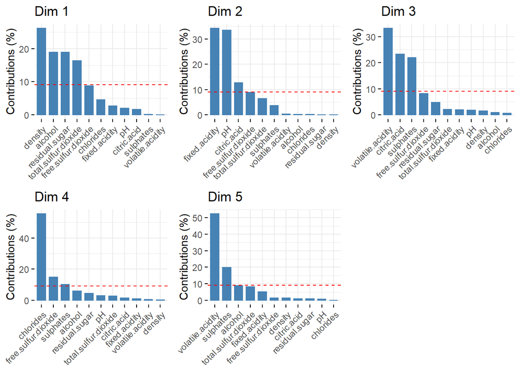

```r
library(factoextra);library(gridExtra)
charts = lapply(1:5,FUN = function(x) fviz_contrib(pca_facto,choice = 'var',axes = x,title=paste('Dim',x)))
grid.arrange(grobs = charts,ncol=3,nrow=2)
```

Next, let us visually examine the relationships between variables. The following plot charts the first two most important components, Dim1 and Dim2 which explains 44% of the total variance. Angle between a variable and component reflects strength of relationship (smaller the angle, stronger the relationship) and the color indicates the contribution of the variable to the first two components. The picture is helpful but one must bear in mind that it only represents the first two components (44% of variance). All five components represent about 72% of variance.

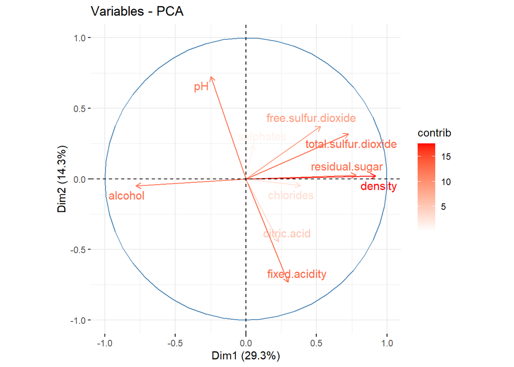

```r
fviz_pca_var(X = pca_facto,col.var = 'contrib',gradient.cols = c('red'),col.circle = 'steelblue',repel = T)
```

# Apply Component Structure

In order to use the components, for downstream analysis, we first apply the component structure to the test set. Next, extract the components. Finally, combine components with other variables in the original dataset.

First, we illustrate this with the FactoMineR object

```r
trainComponents = pca_facto$ind$coord
testComponents = predict(pca_facto,newdata=test)$coord

trainComponents = cbind(trainComponents,quality = train_wine$quality)
testComponents = cbind(testComponents,quality = test_wine$quality)
```

Next, we illustrate the same using prcomp() object. Note: The sign of the scores for prcomp() are the opposite of FactoMineR but the numbers are identical.

```r
trainComponents2 = pca$x[,1:5]
trainComponents2 = cbind(trainComponents2,quality = train_wine$quality)

testComponents2 = predict(pca,newdata = test)[,1:5]
testComponents2 = cbind(testComponents2,quality = test_wine$quality)
```

This file was generated using R Version 4.1.2